# Multi-collinearity

Drew Tyre

5/9/2017

### Discuss

What is multi-collinearity and why is it a problem?

### Demonstrate

We will create some artificial data with different levels of correlation.

```r
set.seed(9377938)
p = 3 # this many variables
# this is the mean vector - set to 0 for now
Means <- rep(0, 3)
# this is the covariance matrix
Sigma <- matrix(c(1, 0, .99,
                  0, 1, 0,
                  .99, 0, 1), nrow= p, ncol = p)
library(MASS)
library(tidyverse)
library(GGally)
```

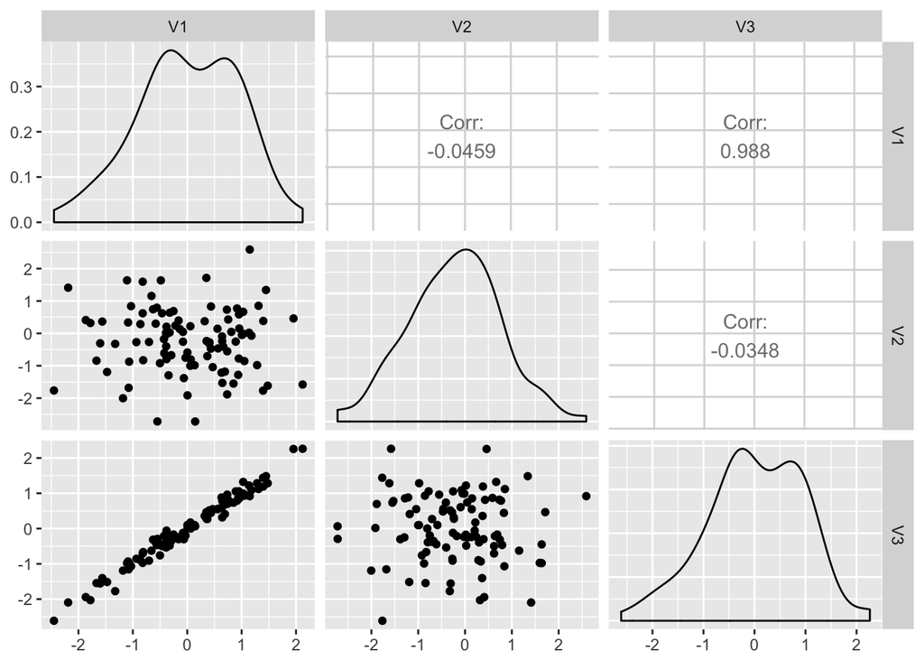

```r
df <- as_data_frame( mvrnorm(n = 100, mu= Means, Sigma=Sigma))
ggpairs(df)
```

Now we are going to create a response variable *y* that is a function of `V1` but not the other two variables. The actual slope doesn’t matter because whatever it is in reality we could rescale the data so it is 1.

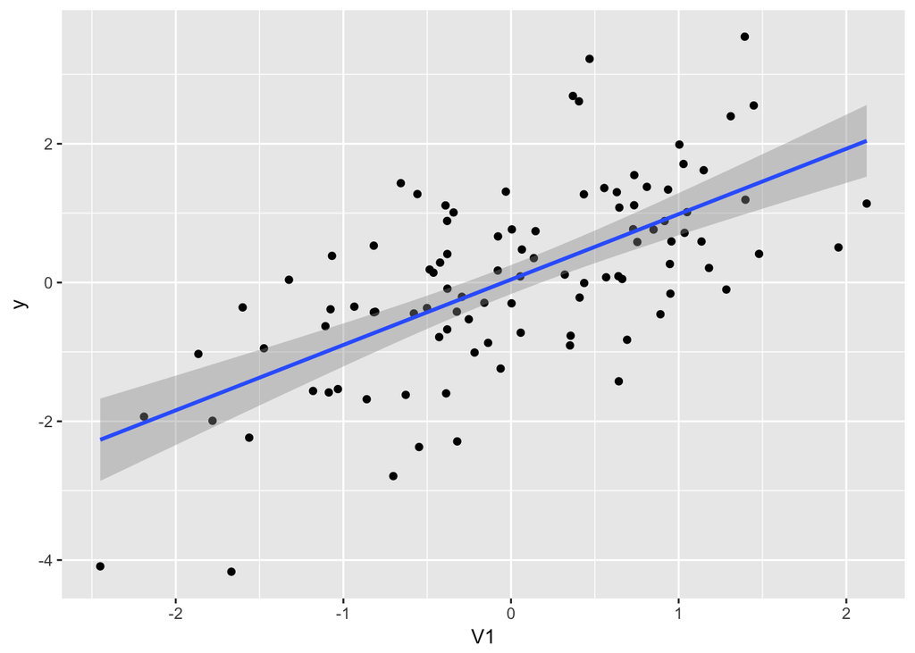

```r
df <- mutate(df, y = V1 + rnorm(n()))
ggplot(df, aes(x = V1, y=y)) + geom_point() +
  geom_smooth(method="lm")
```

Now we want to fit a series of models to this simple dataset to see the effect of including extraneous parameters into the linear model.

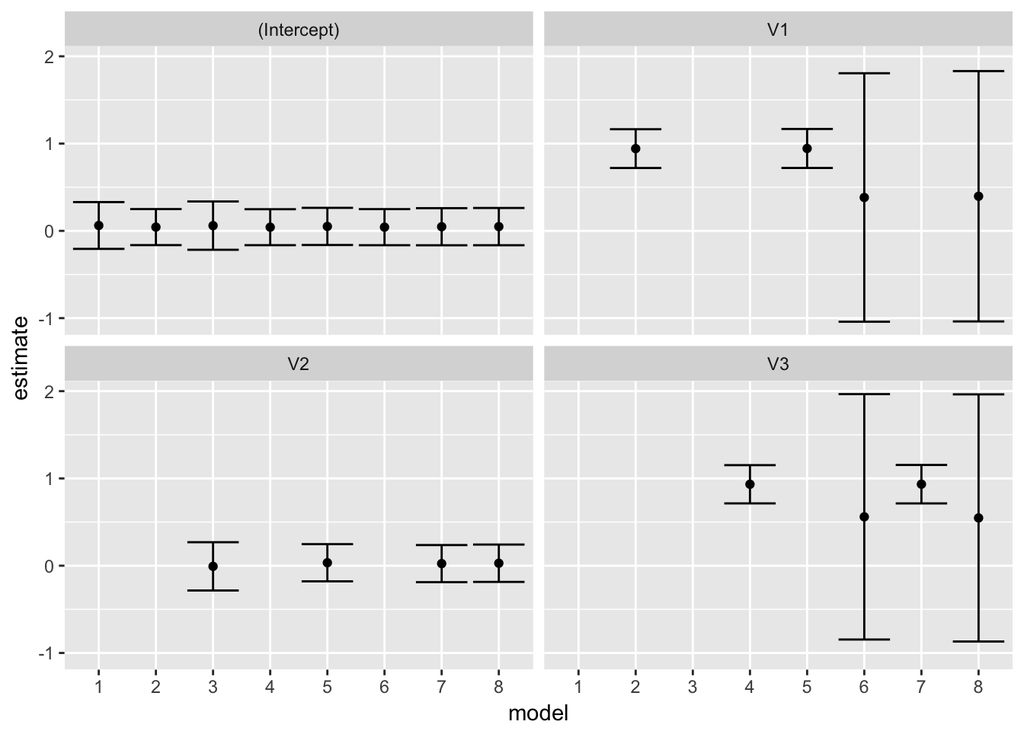

```r
models <- list(y~1,
               y~V1,
               y~V2,
               y~V3,
               y~V1 + V2,
               y~V1 + V3,
               y~V2 + V3,
               y~V1 + V2 + V3)
fits <- map(models, lm, data=df)
library(broom)
coefs <- map_df(fits, tidy, .id = "model")
ggplot(coefs, aes(x = model, y=estimate)) +
         geom_point() +
         facet_wrap(~term) +
         geom_errorbar(aes(ymin = estimate - 1.96*std.error,
                           ymax = estimate + 1.96*std.error))
```

As you can see, including the co-linear variables 1 and 3 in the same model has a huge effect on the standard errors. In addition, the estimate of $\beta_{3}$ changes dramatically depending on whether `V1` is in the model or not.

There is a way to calculate how much bigger the standard error is as a result of multi-collinearity: the Variance Inflation Factor, or VIF for short.

```r
library(car)
vif(fits[[8]])
```

```
##        V1        V2        V3
## 41.113603  1.006754 41.076494
```

What do those numbers actually mean? We can calculate the ratio of the variances of $\beta_3$ in models 7 and 8.

```r
filter(coefs, term == "V3",
       model > 6) %>%
  mutate(variance = std.error^2,
         vif_ = lead(variance)/variance) %>%
  select(vif_)
```

```
##       vif_
## 1 41.32778
## 2       NA
```

So the vif is measuring how much the variance of a term increases when there is multi-collinearity present.